# 607 Lab 6 Project2

Chi Hang(Philip) Cheung, Inna Yedzinovich

2024-10-12

```r
options(repos = c(CRAN = "https://cran.r-project.org"))
library(tidyr)
suppressPackageStartupMessages(library(dplyr))
library(readr)
library(ggplot2)
library(tidyverse)
```

## Dataset 1: SAT scores in 2010

```r
url1<- "https://raw.githubusercontent.com/stormwhale/data-mines/refs/heads/main/SAT__College_Board__2010_School_Level_Results.csv"
df2<- read.csv(url1)
head(df2)
```

|  | DBN | School.Name | Number.of.Test.Takers | Critical.Reading.Mean | Mathematics.Mean | Writing.Mean |
| --- | --- | --- | --- | --- | --- | --- |
| 1 | 01M292 | Henry Street School for International Studies | 31 | 391 | 425 | 385 |
| 2 | 01M448 | University Neighborhood High School | 60 | 394 | 419 | 387 |
| 3 | 01M450 | East Side Community High School | 69 | 418 | 431 | 402 |
| 4 | 01M458 | SATELLITE ACADEMY FORSYTH ST | 26 | 385 | 370 | 378 |
| 5 | 01M509 | CMSP HIGH SCHOOL | NA | NA | NA | NA |
| 6 | 01M515 | Lower East Side Preparatory High School | 154 | 314 | 532 | 314 |

### To tidy up and transform the data:

```r
df2_tidy<- df2 %>%
  pivot_longer(cols = c('Critical.Reading.Mean', 'Mathematics.Mean', 'Writing.Mean'),
               names_to = 'Test_subjects',
               values_to = 'Average_scores',
               names_pattern ='(.*)\\.Mean')
df2_tidy<-rename(df2_tidy,c('Number_of_test_takers'='Number.of.Test.Takers', 'School_name'='School.Name'))

#drop NA schools
df2_tidy<- df2_tidy %>%
  subset(!is.na(Number_of_test_takers))

#check if any NA still exist:
any(sum(is.na(df2_tidy)))
```

```
## [1] FALSE
```

```r
head(df2_tidy)
```

| DBN | School_name | Number_of_test_takers | Test_subjects | Average_scores |
| --- | --- | --- | --- | --- |
| 01M292 | Henry Street School for International Studies | 31 | Critical.Reading | 391 |
| 01M292 | Henry Street School for International Studies | 31 | Mathematics | 425 |
| 01M292 | Henry Street School for International Studies | 31 | Writing | 385 |
| 01M448 | University Neighborhood High School | 60 | Critical.Reading | 394 |
| 01M448 | University Neighborhood High School | 60 | Mathematics | 419 |
| 01M448 | University Neighborhood High School | 60 | Writing | 387 |

### Analyzing the data

To get the top 10 schools ranked by total SAT scores:

```r
top_total<-df2_tidy %>%
  group_by(School_name) %>%
  summarise(total_SAT_score= sum(Average_scores)) %>%
  slice_max(total_SAT_score, n= 10)

print(top_total)
```

```
## # A tibble: 10 × 2
##    School_name                                           total_SAT_score
##    <chr>                                                           <int>
##  1 "STUYVESANT HIGH SCHOOL "                                        2087
##  2 "BRONX HIGH SCHOOL OF SCIENCE "                                  1960
##  3 "STATEN ISLAND TECHNICAL HIGH SCHOOL "                           1928
##  4 "Townsend Harris High School at Queens College "                 1923
##  5 "HS of American Studies at Lehman College "                      1884
##  6 "QUEENS HS FOR SCIENCE YORK COL "                                1875
##  7 "BARD HIGH SCHOOL EARLY COLLEGE "                                1868
##  8 "BROOKLYN TECHNICAL HIGH SCHOOL "                                1821
##  9 "High School For Math Science Engineering City Coll "            1794
## 10 "New York City Laboratory School Collab Studies "                1725
```

### Top 10 schools SAT SCOREs break down by each test subject

```r
top_sub <- df2_tidy %>%
  filter(School_name %in% top_total$School_name)
#To get the mean for each test subject from the top 10 schools:
top_sub_mean<- top_sub %>%
  group_by(Test_subjects) %>%
  summarise(Mean_score = mean(Average_scores))
print(top_sub_mean)
```

```
## # A tibble: 3 × 2
##   Test_subjects    Mean_score
##   <chr>                 <dbl>
## 1 Critical.Reading       620
## 2 Mathematics            650.
## 3 Writing                616.
```

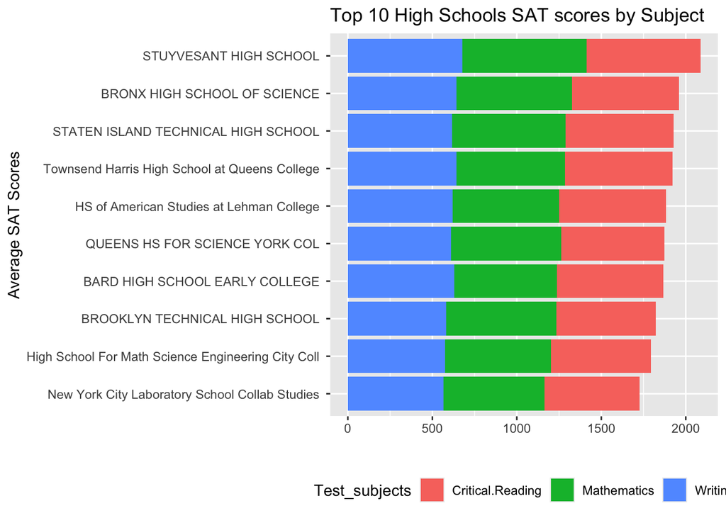

```r
ggplot(top_sub, aes(x=reorder(School_name, Average_scores), y= Average_scores, fill=Test_subjects))+
  geom_bar(stat='identity') +
  coord_flip() +
  labs(title = 'Top 10 High Schools SAT scores by Subject', y='', x ='Average SAT Scores')+
  theme(legend.position = 'bottom')
```

### To look at how far ahead the top 10 schools from the mean scores of other schools:

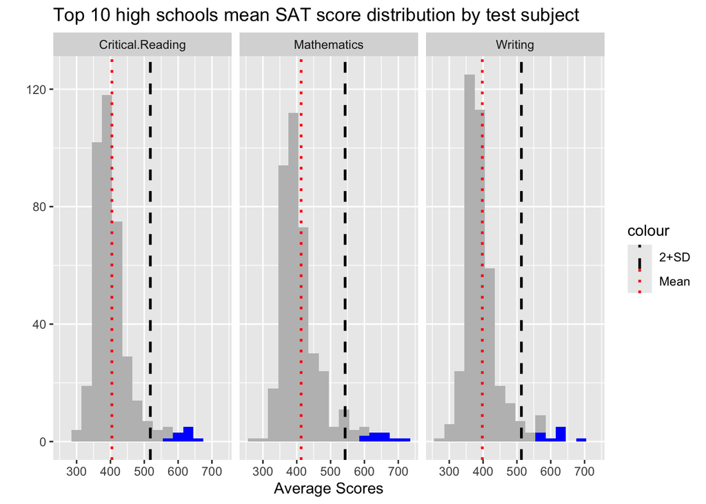

```r
#To get the mean and standard deviation from all HS that took the SAT:
tot_stat<- df2_tidy %>%
  group_by(Test_subjects) %>%
  summarise(Mean_score= mean(Average_scores), SD=sd(Average_scores), '1+SD'=Mean_score+SD, '2+SD'=Mean_score+SD*2)

tot_stat_mean<- tot_stat$Mean_score
tot_stat_2sd<- tot_stat$`2+SD`

ggplot() +
  geom_histogram(data= df2_tidy, aes(x=Average_scores), fill='grey', binwidth=30)+
  geom_histogram(data= top_sub, aes(x=Average_scores), fill='blue', binwidth=30)+
    facet_wrap(~Test_subjects)+
  labs(title = 'Top 10 high schools mean SAT score distribution by test subject',
        y='',
        x='Average Scores') +
  geom_vline(data= tot_stat, aes(xintercept= tot_stat_mean, color ='Mean'), linetype='dotted', linewidth = 0.9)+
  geom_vline(data= tot_stat, aes(xintercept= tot_stat_2sd, color ='2+SD'), linetype='dashed', linewidth=0.9)+
  scale_color_manual(values= c('Mean'='red', '2+SD'='black'))
```

## Conclusion: Top 10 High Schools are above 2 standard Deviation from the mean scores

### Correlation between # of test takers and average SAT scores

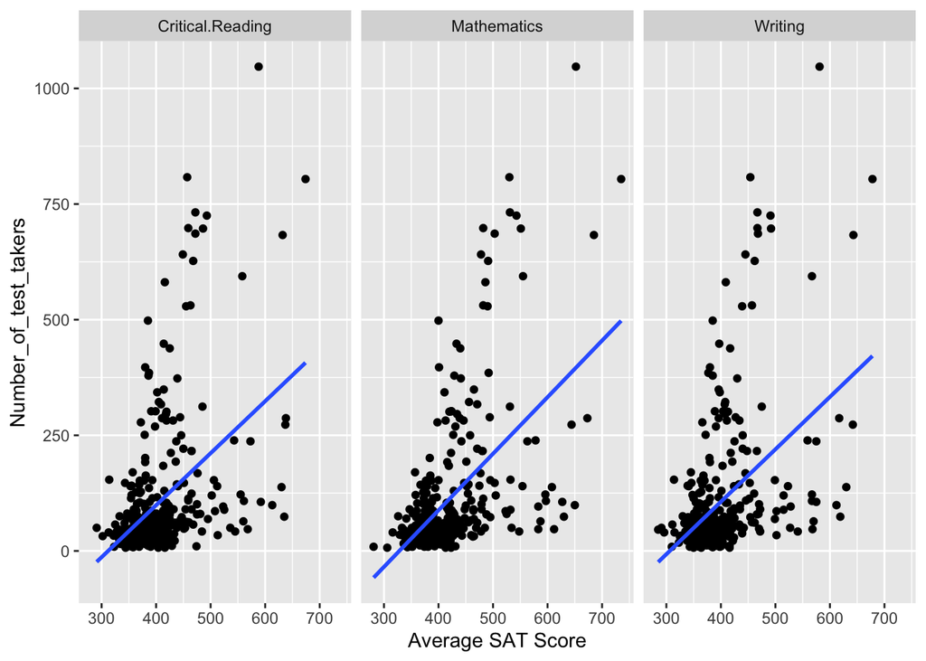

```r
ggplot(df2_tidy, aes(x= Average_scores, y=Number_of_test_takers))+
  geom_point() +
  facet_wrap(~Test_subjects) +
  geom_smooth(method='lm', se=FALSE) +
  labs(x= 'Average SAT Score')
```

There is a positive correlation between number of test takers and average SAT scores. The higher number of people from a school participating in the SAT, the average score is generally higher than the mean value. This is observed in all three test subjects.

## Dataset 2: Unity Data - MTA Daily Ridership

- Date: The date of the record.
- Subways: Total estimated ridership and percentage of comparable pre-pandemic day.
- Buses: Total estimated ridership and percentage of comparable pre-pandemic day.
- LIRR (Long Island Rail Road): Total estimated ridership and percentage of comparable pre-pandemic day.
- Metro-North: Total estimated ridership and percentage of comparable pre-pandemic day.
- Access-A-Ride: Total scheduled trips and percentage of comparable pre-pandemic day.
- Bridges and Tunnels: Total traffic and percentage of comparable pre-pandemic day.
- Staten Island Railway: Total estimated ridership and percentage of comparable pre-pandemic day.

Initial Analysis:  
- There is a noticeable decline in ridership across all transportation modes as the month progresses. - The percentage of ridership compared to pre-pandemic levels shows a significant decline. - Access-A-Ride: This services maintained higher percentages of pre-pandemic levels compared to other modes, indicating continued demand for these services despite the pandemic - Traffic through bridges and tunnels also decreased but not as drastically as public transportation ridership. This could suggest a shift towards private vehicle usege during the pandemic.

```r
url <- "https://raw.githubusercontent.com/Yedzinovich/Data-607/main/MTA_Daily_Ridership_Data.csv"

mta_data <- read_csv(url)
mta_data <- mta_data %>% mutate(Date = as.Date(Date, format = "%m/%d/%y"))

mta_data_long <- mta_data %>% pivot_longer(cols = -Date, names_to = "Metric", values_to = "Value")
head(mta_data_long)
```

| Date | Metric | Value |
| --- | --- | --- |
| 2020-03-01 | Subways: Total Estimated Ridership | 2212965 |
| 2020-03-01 | Subways: % of Comparable Pre-Pandemic Day | 97 |
| 2020-03-01 | Buses: Total Estimated Ridership | 984908 |
| 2020-03-01 | Buses: % of Comparable Pre-Pandemic Day | 99 |
| 2020-03-01 | LIRR: Total Estimated Ridership | 86790 |
| 2020-03-01 | LIRR: % of Comparable Pre-Pandemic Day | 100 |

```r
mta_data_long <- mta_data_long %>% separate(Metric, into = c("Transport_Mode", "Metric_Type"), sep = ": ")
head(mta_data_long)
```

| Date | Transport_Mode | Metric_Type | Value |
| --- | --- | --- | --- |
| 2020-03-01 | Subways | Total Estimated Ridership | 2212965 |
| 2020-03-01 | Subways | % of Comparable Pre-Pandemic Day | 97 |
| 2020-03-01 | Buses | Total Estimated Ridership | 984908 |
| 2020-03-01 | Buses | % of Comparable Pre-Pandemic Day | 99 |
| 2020-03-01 | LIRR | Total Estimated Ridership | 86790 |
| 2020-03-01 | LIRR | % of Comparable Pre-Pandemic Day | 100 |

Now that we have the data in a long format, we can extract more comprehensive insights from it. Long format can help us to perform a variety of analyses that are more flexible and insightful compared to the original wide format.

***What to know: - March 11, 2020, marks the start of the federal COVID-19 PHE declaration. - May 11, 2023, marks the end of the federal COVID-19 PHE declaration. Source:https://archive.cdc.gov/www_cdc_gov/coronavirus/2019-ncov/your-health/end-of-phe.html#:~:text=The%20federal%20COVID%2D19%20PHE,and%20testing%2C%20will%20remain%20available.

```r
# Analysis #1
avg_ridership <- mta_data_long %>%
  filter(Metric_Type == "Total Estimated Ridership") %>%
  group_by(Transport_Mode) %>%
  summarize(Average_Ridership = mean(Value, na.rm = TRUE))

print(avg_ridership)
```

```
## # A tibble: 5 × 2
##   Transport_Mode        Average_Ridership
##   <chr>                             <dbl>
## 1 Buses                          1000673.
## 2 LIRR                            134099.
## 3 Metro-North                     113089.
## 4 Staten Island Railway             4382.
## 5 Subways                        2482768.
```

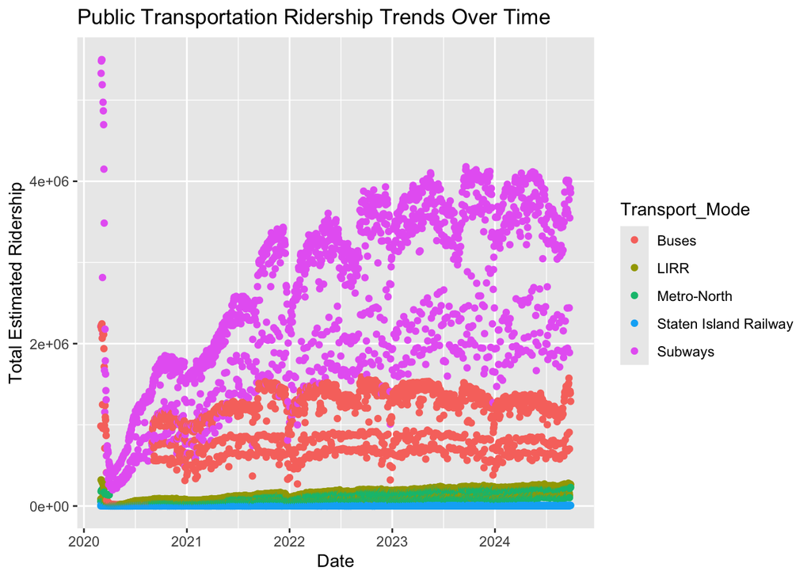

```r
# Analysis #2
ggplot(mta_data_long %>% filter(Metric_Type == "Total Estimated Ridership"), aes(x = Date, y = Value, color = Transport_Mode)) +
  geom_point() +
  labs(title = "Public Transportation Ridership Trends Over Time", x = "Date", y = "Total Estimated Ridership")
```

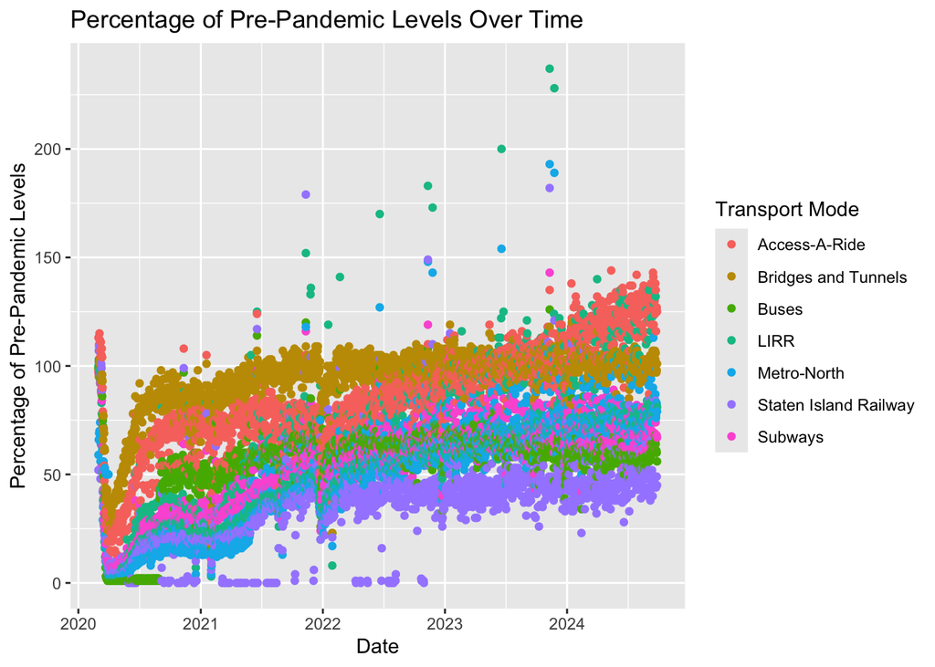

```r
# Analysis #3
percentage_mta_data <- mta_data_long %>%
  filter(grepl("% of Comparable Pre-Pandemic Day", Metric_Type))

ggplot(percentage_mta_data, aes(x = Date, y = Value, color = Transport_Mode)) +
  geom_point() +
  labs(title = "Percentage of Pre-Pandemic Levels Over Time",
       x = "Date",
       y = "Percentage of Pre-Pandemic Levels",
       color = "Transport Mode")
```

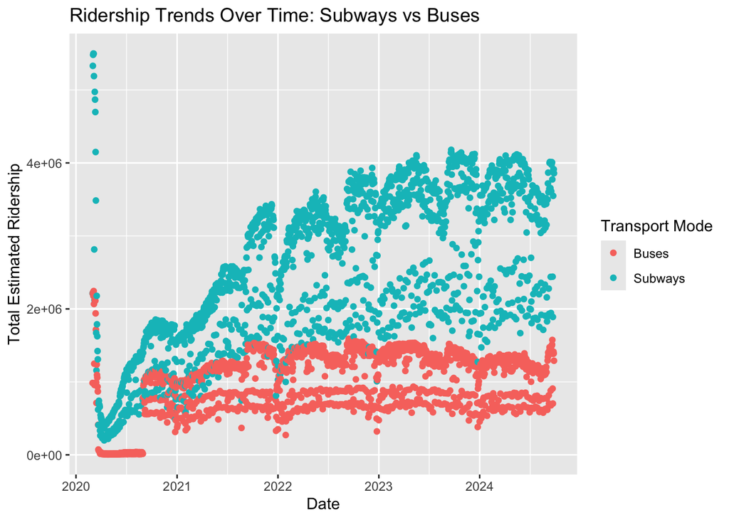

```r
# Analysis 4
pt_mta_ridership_data <- mta_data_long %>%
  filter(Metric_Type == "Total Estimated Ridership")

ggplot(pt_mta_ridership_data %>% filter(Transport_Mode %in% c("Subways", "Buses")),
       aes(x = Date, y = Value, color = Transport_Mode)) +
  geom_point() +
  labs(title = "Ridership Trends Over Time: Subways vs Buses",
       x = "Date",
       y = "Total Estimated Ridership",
       color = "Transport Mode")
```

```r
# Calculate the average ridership for each transport mode during the pandemic
avg_ridership_pandemic <- pt_mta_ridership_data %>%
  filter(Date >= as.Date("2020-03-01") & Date <= as.Date("2023-05-11")) %>%
  group_by(Transport_Mode) %>%
  summarize(Average_Ridership = mean(Value, na.rm = TRUE))

print(avg_ridership_pandemic)
```

```
## # A tibble: 5 × 2
##   Transport_Mode        Average_Ridership
##   <chr>                             <dbl>
## 1 Buses                           952938.
## 2 LIRR                            108023.
## 3 Metro-North                      88261.
## 4 Staten Island Railway             3890.
## 5 Subways                        2185483.
```

```r
# Analysis 5
pre_pandemic <- pt_mta_ridership_data %>%
  filter(Date >= as.Date("2020-03-01") & Date <= as.Date("2020-03-11"))
print(pre_pandemic)
```

```
## # A tibble: 55 × 4
##    Date       Transport_Mode        Metric_Type                 Value
##    <date>     <chr>                 <chr>                       <dbl>
##  1 2020-03-01 Subways               Total Estimated Ridership 2212965
##  2 2020-03-01 Buses                 Total Estimated Ridership  984908
##  3 2020-03-01 LIRR                  Total Estimated Ridership   86790
##  4 2020-03-01 Metro-North           Total Estimated Ridership   55825
##  5 2020-03-01 Staten Island Railway Total Estimated Ridership    1636
##  6 2020-03-02 Subways               Total Estimated Ridership 5329915
##  7 2020-03-02 Buses                 Total Estimated Ridership 2209066
##  8 2020-03-02 LIRR                  Total Estimated Ridership  321569
##  9 2020-03-02 Metro-North           Total Estimated Ridership  180701
## 10 2020-03-02 Staten Island Railway Total Estimated Ridership   17140
## # ℹ 45 more rows
```

```r
post_pandemic <- pt_mta_ridership_data %>%
  filter(Date >= as.Date("2023-05-12") & Date <= as.Date("2024-10-10"))
print(post_pandemic)
```

```
## # A tibble: 2,520 × 4
##    Date       Transport_Mode        Metric_Type                 Value
##    <date>     <chr>                 <chr>                       <dbl>
##  1 2023-05-12 Subways               Total Estimated Ridership 3723192
##  2 2023-05-12 Buses                 Total Estimated Ridership 1436385
##  3 2023-05-12 LIRR                  Total Estimated Ridership  201367
##  4 2023-05-12 Metro-North           Total Estimated Ridership  185027
##  5 2023-05-12 Staten Island Railway Total Estimated Ridership    6629
##  6 2023-05-13 Subways               Total Estimated Ridership 2487178
##  7 2023-05-13 Buses                 Total Estimated Ridership  918257
##  8 2023-05-13 LIRR                  Total Estimated Ridership  113810
##  9 2023-05-13 Metro-North           Total Estimated Ridership  109940
## 10 2023-05-13 Staten Island Railway Total Estimated Ridership    1973
## # ℹ 2,510 more rows
```

```r
avg_pre_pandemic <- pre_pandemic %>%
  group_by(Transport_Mode) %>%
  summarize(Average_Ridership_Pre = mean(Value, na.rm = TRUE))
print(avg_pre_pandemic)
```

```
## # A tibble: 5 × 2
##   Transport_Mode        Average_Ridership_Pre
##   <chr>                                 <dbl>
## 1 Buses                              1860634.
## 2 LIRR                                236933.
## 3 Metro-North                         154002.
## 4 Staten Island Railway                12476.
## 5 Subways                            4425676.
```

```r
avg_post_pandemic <- post_pandemic %>%
  group_by(Transport_Mode) %>%
  summarize(Average_Ridership_Post = mean(Value, na.rm = TRUE))
print(avg_post_pandemic)
```

```
## # A tibble: 5 × 2
##   Transport_Mode        Average_Ridership_Post
##   <chr>                                  <dbl>
## 1 Buses                               1111202.
## 2 LIRR                                 194476.
## 3 Metro-North                          170578.
## 4 Staten Island Railway                  5523.
## 5 Subways                             3171124.
```

```r
avg_ridership <- merge(avg_pre_pandemic, avg_post_pandemic, by = "Transport_Mode")
print(avg_ridership)
```

```
##          Transport_Mode Average_Ridership_Pre Average_Ridership_Post
## 1                 Buses            1860634.45            1111202.327
## 2                  LIRR             236932.91             194476.022
## 3           Metro-North             154001.82             170578.192
## 4 Staten Island Railway              12476.09               5523.302
## 5               Subways            4425676.18            3171124.308
```

```r
avg_ridership <- avg_ridership %>%
  mutate(Percentage_Change = ((Average_Ridership_Post - Average_Ridership_Pre) / Average_Ridership_Pre) * 100)
print(avg_ridership)
```

```
##          Transport_Mode Average_Ridership_Pre Average_Ridership_Post
## 1                 Buses            1860634.45            1111202.327
## 2                  LIRR             236932.91             194476.022
## 3           Metro-North             154001.82             170578.192
## 4 Staten Island Railway              12476.09               5523.302
## 5               Subways            4425676.18            3171124.308
##   Percentage_Change
## 1         -40.27831
## 2         -17.91937
## 3          10.76375
## 4         -55.72891
## 5         -28.34712
```

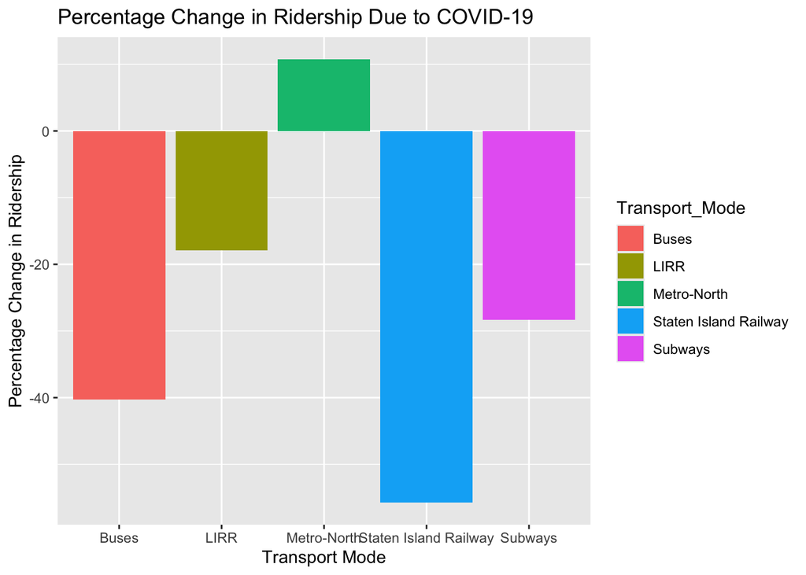

```r
ggplot(avg_ridership, aes(x = Transport_Mode, y = Percentage_Change, fill = Transport_Mode)) +
  geom_bar(stat = "identity") +
  labs(title = "Percentage Change in Ridership Due to COVID-19",
       x = "Transport Mode",
       y = "Percentage Change in Ridership")
```

#### Analysis:

##### 1- Analyze the average ridership for each transport mode.

The data shows that subways have the most riders, with about 2.48 million people using them daily, much more than other types of transport. Buses come next, with around 1 million riders each day, making them very important. LIRR and Metro-North have fewer riders, with around 134,000 and 113,000 daily, since they serve commuters in specific regions. Staten Island Railway has the fewest riders, just over 4,000, likely because it covers a smaller area. Overall, subways and buses are the main ways people get around in the city.

##### 5- Analyze the impact of the COVID-19 pandemic on ridership by comparing pre-pandemic and post-pandemic data.

The graph illustrates that most MTA transportation systems experienced a decline in ridership due to the COVID-19 pandemic, with Staten Island Railroad suffering the largest decrease, with over 50% fewer passengers. In contrast, Metro-North has seen an increase in ridership, likely due to people relocating from New York City during the pandemic and opting to commute using Metro-North.

## Dataset 3: K-12 Schools diversity from 1994-2017 in all states

```r
url3<- "https://raw.githubusercontent.com/stormwhale/data-mines/refs/heads/main/school%20divers.csv"
df3<-read.csv(url3)
head(df3)
```

|  | X.1 | X | LEAID | LEA_NAME | ST | d_Locale_Txt | SCHOOL_YEAR | AIAN | Asian | Black | Hispanic | White | Multi | Total | diverse | variance | int_group |
| --- | --- | --- | --- | --- | --- | --- | --- | --- | --- | --- | --- | --- | --- | --- | --- | --- | --- |
| 1 | 1 | 1 | 100002 | alabama youth services | AL | NA | 1994-1995 | 0.00000000 | 0.5893910 | 71.7092338 | 0.1964637 | 27.50491 | NA | 509 | Diverse | NA | NA |
| 2 | 2 | 2 | 100005 | albertville city | AL | town-distant | 1994-1995 | 0.00000000 | 0.3207184 | 1.2828736 | 4.5221296 | 93.87428 | NA | 3118 | Extremely undiverse | NA | NA |
| 3 | 3 | 3 | 100005 | albertville city | AL | town-distant | 2016-2017 | 0.29373967 | 0.5507619 | 3.1944189 | 46.7413255 | 46.77804 | 2.441711 | 5447 | Diverse | 0.01155608 | Highly integrated |
| 4 | 4 | 4 | 100006 | marshall county | AL | rural-distant | 1994-1995 | 0.10436857 | 0.1341882 | 0.3727449 | 0.9094975 | 98.47920 | NA | 6707 | Extremely undiverse | NA | NA |
| 5 | 5 | 5 | 100006 | marshall county | AL | rural-distant | 2016-2017 | 0.49235098 | 0.2989274 | 1.0726218 | 21.2941797 | 75.80447 | 1.037454 | 5687 | Undiverse | NA | NA |
| 6 | 6 | 6 | 100007 | hoover city | AL | city-small | 1994-1995 | 0.06518055 | 1.6034415 | 6.0357189 | 0.5475166 | 91.74814 | NA | 7671 | Extremely undiverse | NA | NA |

Cleaning and tidying the dataset. The racial groups are already represented in percentage for each school. NA values are assumed to be 0. All percentage will be rounded to the nearest tenth value.

```r
df3_tidy<- df3 %>%
  mutate_all(~replace(., is.na(.), 0)) %>%
  pivot_longer(cols = AIAN:Multi,
               names_to = 'Ethnicity',
               values_to = 'Student_percentage') %>%
  mutate(Student_percentage=round(as.numeric(Student_percentage),1))

head(df3_tidy)
```

| X.1 | X | LEAID | LEA_NAME | ST | d_Locale_Txt | SCHOOL_YEAR | Total | diverse | variance | int_group | Ethnicity | Student_percentage |
| --- | --- | --- | --- | --- | --- | --- | --- | --- | --- | --- | --- | --- |
| 1 | 1 | 100002 | alabama youth services | AL | 0 | 1994-1995 | 509 | Diverse | 0 | 0 | AIAN | 0.0 |
| 1 | 1 | 100002 | alabama youth services | AL | 0 | 1994-1995 | 509 | Diverse | 0 | 0 | Asian | 0.6 |
| 1 | 1 | 100002 | alabama youth services | AL | 0 | 1994-1995 | 509 | Diverse | 0 | 0 | Black | 71.7 |
| 1 | 1 | 100002 | alabama youth services | AL | 0 | 1994-1995 | 509 | Diverse | 0 | 0 | Hispanic | 0.2 |
| 1 | 1 | 100002 | alabama youth services | AL | 0 | 1994-1995 | 509 | Diverse | 0 | 0 | White | 27.5 |
| 1 | 1 | 100002 | alabama youth services | AL | 0 | 1994-1995 | 509 | Diverse | 0 | 0 | Multi | 0.0 |

### Data analysis:

### 1) Overall ethnicity distribution of K-12 students:

Asian and AIAN groups seem to be the most under integrated among different schools. (See plot below)

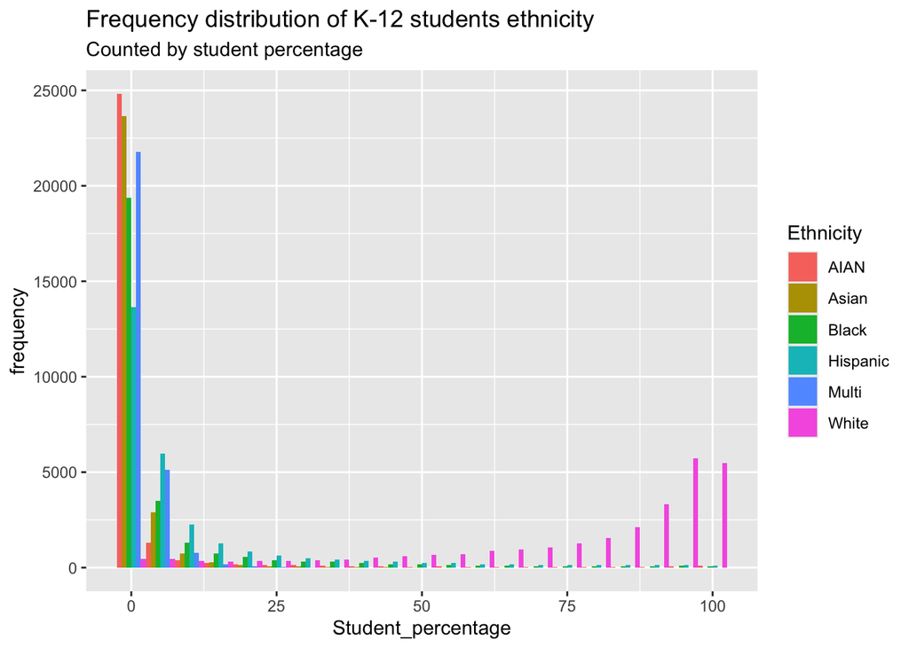

```r
ggplot(df3_tidy, aes(x=Student_percentage, fill=Ethnicity)) +
  geom_histogram(binwidth = 5, position='dodge') +
  labs(y='frequency',
       title = 'Frequency distribution of K-12 students ethnicity',
       subtitle = 'Counted by student percentage')
```

### In 2016-2017, which states have schools that integrated at least 50% Asian and AIAN students?

```r
df3_2017<- df3_tidy %>%
  filter(SCHOOL_YEAR=='2016-2017') %>%
  filter((Ethnicity =='Asian' | Ethnicity == 'AIAN') & Student_percentage >= 50) %>%
  group_by(ST, Ethnicity) %>%
  summarize(mean_percentage = mean(Student_percentage), .groups = 'drop') %>%
  arrange(desc(mean_percentage))

print(df3_2017)
```

```
## # A tibble: 24 × 3
##    ST    Ethnicity mean_percentage
##    <chr> <chr>               <dbl>
##  1 WY    AIAN                 97.2
##  2 ND    AIAN                 91.6
##  3 AZ    AIAN                 90.2
##  4 MT    AIAN                 86.7
##  5 NE    AIAN                 85.5
##  6 WI    AIAN                 83.3
##  7 AK    AIAN                 81.7
##  8 MN    AIAN                 81.0
##  9 NM    AIAN                 80.1
## 10 SD    AIAN                 76.4
## # ℹ 14 more rows
```

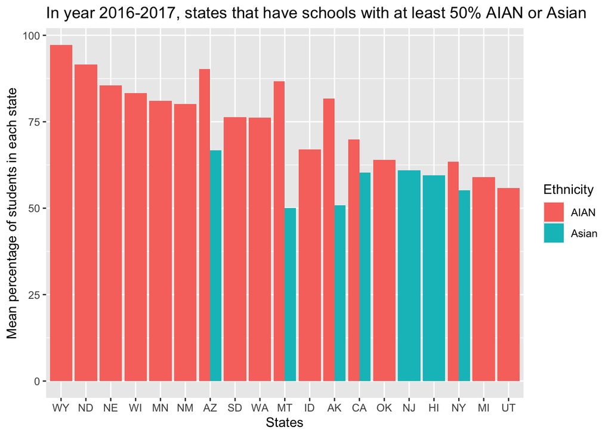

```r
ggplot(df3_2017, aes(x=reorder(ST, -mean_percentage), y=mean_percentage, fill= Ethnicity)) +
  geom_bar(stat='identity', position = 'dodge') +
  labs(title = 'In year 2016-2017, states that have schools with at least 50% AIAN or Asian',
       x='States',
       y='Mean percentage of students in each state')
```

### 2) - Between State Comparisons, compare the integration levels of different ethnic groups between states to see which states are more integrated.

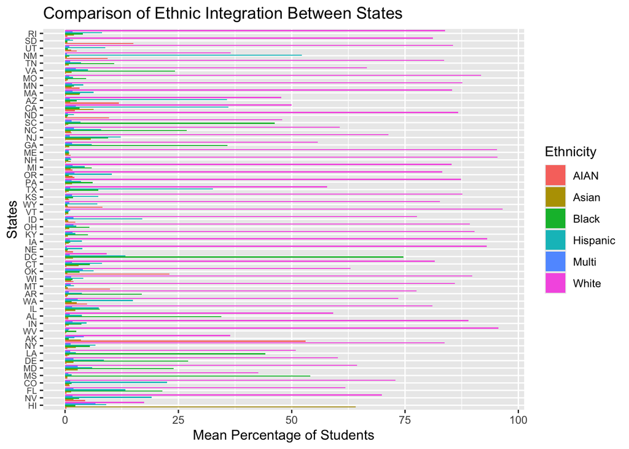

```r
df3_state_comparison <- df3_tidy %>%
  group_by(ST, Ethnicity) %>%
  summarize(mean_percentage = mean(Student_percentage), .groups = 'drop') %>%
  arrange(desc(mean_percentage))

ggplot(df3_state_comparison, aes(x=reorder(ST, -mean_percentage), y=mean_percentage, fill=Ethnicity)) +
  geom_bar(stat='identity', position='dodge') +
  labs(title = 'Comparison of Ethnic Integration Between States',
       x='States',
       y='Mean Percentage of Students') +
  coord_flip() +
  theme(axis.text.y= element_text(size = 7))
```

#### Analysis 2: Between State Comparison

The graph compares the ethnic integration of students in various states, showing the mean percentage of different racial groups in schools. White students make up the largest proportion of students in most states, often exceeding 50% and even approaching 100% in several. Hispanic, Black, and Asian students are represented at lower percentages across states, with some variation. AIAN students and students of multiple races have smaller but noticeable percentages in some states. The chart highlights significant racial differences in student populations across states, with White students being the most dominant group.